# Big Data And Cloud Computing Final Project Technical Report

[figure not shown]

## Executive Summary

This report explores the prediction of win or loss outcomes in *Clash Royale* dataset with 130M matches filtered down to 1v1 ranked matches with 12M games. Each game record contains information on player trophies and the decks of cards used. Feature engineering was done focused on deriving a "net score" for each card, representing its average contribution to crowns earned, along with other features such as trophies and card descriptions to enhance predictive modeling with SparkML. The dataset is well-balanced, with win and loss outcomes distributed evenly, with PCC (Proportional Chance Criterion) value of 50%, benchmark accuracy to beat is calculated as 1.25 times the PCC at 62.5% accuracy.

SparkML models used were LogisticRegression, RandomForestClassifier, GBTClassifier and LinearSVC. Initial best model was Linear Support Vector Classifier (LinearSVC) which achieved 99% accuracy, but this performance was primarily driven by player trophies, identified as a dominant predictor. To eliminate this dependency, models were retrained after removing player trophies as a feature. Without player trophies, the Gradient Boosted Trees Classifier (GBTClassifier) emerged as the best-performing model, achieving a robust 94% accuracy. The top predictor in this revised model was features related to the sum of the net scores of the cards in each player's deck, underscoring the importance of card composition in determining match outcomes.

## Introduction

Clash Royale a game developed by Supercell, is a real-time strategy game that combines card collecting, tower defense, and multiplayer battles with 13 million average monthly active players in 2022. Players deploy cards to attack opponent's towers and defend their own. a game is won by destroying the opponent’s towers while protecting your own. Each player has three towers: one King Tower and two Crown Towers. Destroying the opponent’s King Tower results in an automatic victory, regardless of the status of the Crown Towers. If the King Tower remains standing, the match is decided by the number of Crown Towers destroyed within the three-minute regulation time. In the event of a tie, the game enters a sudden-death overtime period, where the first player to destroy any tower wins. If no towers are destroyed during overtime, the player with the most damage dealt to towers is declared the winner. This structure encourages a blend of aggressive strategies to seize victory and defensive tactics to mitigate losses, adding depth to the competitive gameplay. Matches demand quick thinking and tactical precision

## Problem Statement

The central question of this report is: What features best determine triumph or defeat in Clash Royale 1v1 ranked matches? By analyzing player attributes, deck composition, and engineered features, the goal is to identify the most influential factors driving match outcomes.

## Methodology

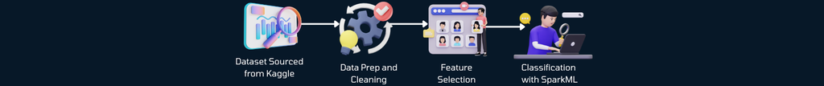

In this section, the report delves into the critical components of the analysis, beginning with an overview of the dataset and its key attributes. The subsequent subsection focuses on data preparation and cleaning, ensuring the dataset is structured and reliable for modeling. Feature selection is then explored, highlighting the process of identifying and engineering the most relevant predictors. Finally, the discussion transitions to SparkML, detailing the implementation of machine learning models to predict match outcomes effectively.

Initialize clean spark session, install dependencies.

```python
spark
```

```
VBox()
```

```
Starting Spark application
```

| ID | YARN Application ID | Kind | State | Spark UI | Driver log | User | Current session? |
| --- | --- | --- | --- | --- | --- | --- | --- |
| 0 | application_1732598159740_0001 | pyspark | idle | [Link](http://ip-172-31-10-172.ec2.internal:20888/proxy/application_1732598159740_0001/) | [Link](http://ip-172-31-2-118.ec2.internal:8042/node/containerlogs/container_1732598159740_0001_01_000001/livy) | None | ✔ |

```
FloatProgress(value=0.0, bar_style='info', description='Progress:', layout=Layout(height='25px', width='50%'),…
```

```
SparkSession available as 'spark'.
```

```
FloatProgress(value=0.0, bar_style='info', description='Progress:', layout=Layout(height='25px', width='50%'),…
```

```
<pyspark.sql.session.SparkSession object at 0x7fb7c8579d30>
```

```python
sc.install_pypi_package('python-dateutil==2.8.2')
sc.install_pypi_package('matplotlib')
sc.install_pypi_package('pandas')
```

```
VBox()
```

```
FloatProgress(value=0.0, bar_style='info', description='Progress:', layout=Layout(height='25px', width='50%'),…
```

[output not shown]

```python
from pyspark.sql import functions as F
from pyspark.ml import Pipeline
from pyspark.ml.classification import RandomForestClassifier, LinearSVC, LogisticRegression, GBTClassifier
from pyspark.ml.feature import IndexToString, StringIndexer
from pyspark.sql.types import IntegerType
from pyspark.ml.feature import VectorAssembler
from pyspark.mllib.classification import LogisticRegressionWithLBFGS
from pyspark.ml.evaluation import MulticlassClassificationEvaluator
from pyspark.ml.feature import StandardScaler
import numpy as np
import matplotlib.pyplot as plt
```

```
VBox()
```

```
FloatProgress(value=0.0, bar_style='info', description='Progress:', layout=Layout(height='25px', width='50%'),…
```

```python
spark.catalog.clearCache()
```

```
VBox()
```

```
FloatProgress(value=0.0, bar_style='info', description='Progress:', layout=Layout(height='25px', width='50%'),…
```

### Clash Royale Dataset

The dataset we used are split into two content types:

- Games info - contains games info, player trophies and card decks used by the players
- Cards info - description of card's attributes like elixir cost, rarity, card type, etc.

```python
df = spark.read.csv(
    "s3://bdcc-dataset/clash-royale/*/*/*.csv",
schema="""
datetime STRING,
gamemode STRING,
p1_tag STRING,
p1_trophies LONG,
p1_crowns LONG,
p1_card1 STRING,
p1_card2 STRING,
p1_card3 STRING,
p1_card4 STRING,
p1_card5 STRING,
p1_card6 STRING,
p1_card7 STRING,
p1_card8 STRING,
p2_tag STRING,
p2_trophies LONG,
p2_crowns LONG,
p2_card1 STRING,
p2_card2 STRING,
p2_card3 STRING,
p2_card4 STRING,
p2_card5 STRING,
p2_card6 STRING,
p2_card7 STRING,
p2_card8 STRING
"""
)
df.printSchema()
```

```
VBox()
```

```
FloatProgress(value=0.0, bar_style='info', description='Progress:', layout=Layout(height='25px', width='50%'),…
```

```
root
 |-- datetime: string (nullable = true)
 |-- gamemode: string (nullable = true)
 |-- p1_tag: string (nullable = true)
 |-- p1_trophies: long (nullable = true)
 |-- p1_crowns: long (nullable = true)
 |-- p1_card1: string (nullable = true)
 |-- p1_card2: string (nullable = true)
 |-- p1_card3: string (nullable = true)
 |-- p1_card4: string (nullable = true)
 |-- p1_card5: string (nullable = true)
 |-- p1_card6: string (nullable = true)
 |-- p1_card7: string (nullable = true)
 |-- p1_card8: string (nullable = true)
 |-- p2_tag: string (nullable = true)
 |-- p2_trophies: long (nullable = true)
 |-- p2_crowns: long (nullable = true)
 |-- p2_card1: string (nullable = true)
 |-- p2_card2: string (nullable = true)
 |-- p2_card3: string (nullable = true)
 |-- p2_card4: string (nullable = true)
 |-- p2_card5: string (nullable = true)
 |-- p2_card6: string (nullable = true)
 |-- p2_card7: string (nullable = true)
 |-- p2_card8: string (nullable = true)
```

```python
cards = spark.read.json("s3://bdcc-dataset/cards_i18n.json", multiLine=True).select(
    "key", "name", "sc_key", "elixir", "type", "rarity",
    "arena", "description", "id", "evolved_spells_sc_key", "is_evolved"
)
cards.printSchema()
```

```
VBox()
```

```
FloatProgress(value=0.0, bar_style='info', description='Progress:', layout=Layout(height='25px', width='50%'),…
```

```
root
 |-- key: string (nullable = true)
 |-- name: string (nullable = true)
 |-- sc_key: string (nullable = true)
 |-- elixir: long (nullable = true)
 |-- type: string (nullable = true)
 |-- rarity: string (nullable = true)
 |-- arena: long (nullable = true)
 |-- description: string (nullable = true)
 |-- id: long (nullable = true)
 |-- evolved_spells_sc_key: string (nullable = true)
 |-- is_evolved: boolean (nullable = true)
```

## Data Prep and Cleaning

Filters:

- Ranked 1v1 Game Mode Only
- Filter out duplicate rows with `dropDuplicates` (removes rows with all identical column values)
- Filter out ties
- Games filtered to `percent_diff_trophies` < 0.50

```python
df = (df.filter(df.gamemode == "72000323")
    .dropDuplicates()
    .withColumn(
        "p1_win",
        F.when(F.col("p1_crowns") > F.col("p2_crowns"), 1)
         .when(F.col("p1_crowns") < F.col("p2_crowns"), -1)
         .otherwise(0)
    )
    .filter(F.col("p1_win") != 0)
    .withColumn("datetime", F.to_timestamp("datetime", "yyyyMMdd'T'HHmmss.SSS'Z'"))
    .withColumn("abs_diff_trophies", F.abs(F.col("p1_trophies")-F.col("p2_trophies")))
    .withColumn(
        "percent_diff_trophies",
        (F.abs(F.col("p1_trophies") - F.col("p2_trophies")) / ((F.col("p1_trophies") + F.col("p2_trophies")) / 2))
    ).filter(F.col("percent_diff_trophies") < 0.50)
    .withColumn(
        "winner_trophies",
        F.when(F.col("p1_win") == 1, F.col("p1_trophies"))
         .otherwise(F.col("p2_trophies"))
    ).withColumn(
        "loser_trophies",
        F.when(F.col("p1_win") == -1, F.col("p2_trophies"))
         .otherwise(F.col("p1_trophies"))
    )
)
```

```
VBox()
```

```
FloatProgress(value=0.0, bar_style='info', description='Progress:', layout=Layout(height='25px', width='50%'),…
```

```python
df.cache()
df.count()
```

```
VBox()
```

```
FloatProgress(value=0.0, bar_style='info', description='Progress:', layout=Layout(height='25px', width='50%'),…
```

```
12449181
```

```python
df.createOrReplaceTempView('data')
cards.createOrReplaceTempView('cards')
```

```
VBox()
```

```
FloatProgress(value=0.0, bar_style='info', description='Progress:', layout=Layout(height='25px', width='50%'),…
```

## Train-Test Split and Feature Selection

#### Train Test Split Selection

```python
grouped = df.groupBy(F.date_format("datetime", "yyyy-MM").alias("year_month")) \
            .agg(F.count("*").alias("count"))
total_count = df.count()
result = grouped.withColumn("percentage", F.round((F.col("count") / F.lit(total_count)) * 100, 2))
result.orderBy("year_month").show(truncate=False)
```

```
VBox()
```

```
FloatProgress(value=0.0, bar_style='info', description='Progress:', layout=Layout(height='25px', width='50%'),…
```

```
+----------+-------+----------+
|year_month|count  |percentage|
+----------+-------+----------+
|2022-10   |28     |0.0       |
|2022-11   |932723 |7.49      |
|2022-12   |1004329|8.07      |
|2023-01   |1048991|8.43      |
|2023-02   |901591 |7.24      |
|2023-03   |954726 |7.67      |
|2023-04   |5      |0.0       |
|2023-05   |1345381|10.81     |
|2023-06   |1147216|9.22      |
|2023-07   |1031887|8.29      |
|2023-08   |1574062|12.64     |
|2023-09   |900980 |7.24      |
|2023-10   |1156583|9.29      |
|2023-11   |450679 |3.62      |
+----------+-------+----------+
```

- Split test set = 2023-08 to 2023-11 $\approx$ 32.79% of total
- Train set = 2023-07 and earlier $\approx$ 67.21% of total

Split is done this way so that game matches from an earlier timeframe is used to predict matches at future timeframe instead of randomly shuffling the data and doing a split.

#### Feature selection

Features and Class labels are described below

- `p1_win` - if p1 has more crowns than p1
- `abs_diff_trophies` - absolute difference of `p1_trophies` and `p2_trophies`
- `percent_diff_trophies` - absolute percentage difference of `p1_trophies` and `p2_trophies`
- `winner_trophies` - `p1_trophies` if p1 is winner else `p2_trophies`
- `loser_trophies` - `p1_trophies` if p1 is loser else `p2_trophies`

In the query below is used to calculate a "net score" associated to a specific card. It is determined by looking at a history of games and working out on average how much a card has contributed in gaining a crown. Calculated netscores are based on matches dated 2023-07 and earlier.

```python
ranked_cardscores = spark.sql('''
SELECT up.card, c.name, c.elixir, c.type, c.rarity, c.is_evolved,
    COUNT(1) lineups_played,
    AVG(CASE WHEN up.player = 'p1' THEN p1_crowns
        ELSE p2_crowns END) crowns_generated,
    AVG(CASE WHEN up.player = 'p1' THEN p2_crowns
        ELSE p1_crowns END) crowns_allowed,
    AVG(CASE WHEN up.player = 'p1' THEN p1_crowns - p2_crowns
        ELSE p2_crowns - p1_crowns END) net_score
FROM data UNPIVOT (
    card for player in (
        p1_card1 as p1, p1_card2 as p1, p1_card3 as p1, p1_card4 as p1,
        p1_card5 as p1, p1_card6 as p1, p1_card7 as p1, p1_card8 as p1,
        p2_card1 as p2, p2_card2 as p2, p2_card3 as p2, p2_card4 as p2,
        p2_card5 as p2, p2_card6 as p2, p2_card7 as p2, p2_card8 as p2
    )
) up
INNER JOIN cards c ON up.card = c.id
WHERE gamemode = 72000323 -- Ranked1v1 only
    AND CAST(datetime AS DATE) <= '2023-07-31'
GROUP BY up.card, c.name, c.elixir, c.type, c.rarity, c.is_evolved
''')
ranked_cardscores.cache()
print("Best cards:")
ranked_cardscores.orderBy("net_score", ascending=False).show(10)
print("Wosrt cards:")
ranked_cardscores.orderBy("net_score", ascending=True).show(10)
```

```
VBox()
```

```
FloatProgress(value=0.0, bar_style='info', description='Progress:', layout=Layout(height='25px', width='50%'),…
```

```
Best cards:
+--------+----------------+------+--------+---------+----------+--------------+------------------+------------------+-------------------+
|    card|            name|elixir|    type|   rarity|is_evolved|lineups_played|  crowns_generated|    crowns_allowed|          net_score|
+--------+----------------+------+--------+---------+----------+--------------+------------------+------------------+-------------------+
|26000060|    Goblin Giant|     6|   Troop|     Epic|     false|        373743|1.0231549487214475|0.9071099659391614|0.11604498278228623|
|28000016|     Heal Spirit|     1|   Troop|     Rare|     false|        545008|0.9991192789830609|0.8888328244723013|0.11028645451075947|
|26000043|Elite Barbarians|     6|   Troop|   Common|     false|       1039242|1.0629237463458945|0.9602008001986063|0.10272294614728812|
|26000028|Three Musketeers|     9|   Troop|     Rare|     false|        381028|0.9522292324973493|0.8496672160576125|0.10256201643973671|
|26000033|          Sparky|     6|   Troop|Legendary|     false|        631344|1.0139638612230417|0.9139581591018525|0.10000570212118909|
|27000007|Elixir Collector|     6|Building|     Rare|     false|       1009790|1.0096386377365592|0.9151496845878846|0.09448895314867448|
|28000002|            Rage|     2|   Spell|     Epic|     false|        941126|1.1449858998688804|1.0538461374991235|0.09113976236975707|
|26000008|      Barbarians|     5|   Troop|   Common|     false|        960818| 1.029591452283367|0.9607053573101253|0.06888609497324155|
|26000003|           Giant|     5|   Troop|     Rare|     false|        692611|0.9745008381328047|0.9077866219277487|0.06671421620505594|
|26000022|    Minion Horde|     5|   Troop|   Common|     false|        533745|0.9520932280396069|0.8862078333286495|0.06588539471095747|
+--------+----------------+------+--------+---------+----------+--------------+------------------+------------------+-------------------+
only showing top 10 rows

Wosrt cards:
+--------+--------------+------+--------+------+----------+--------------+------------------+------------------+--------------------+
|    card|          name|elixir|    type|rarity|is_evolved|lineups_played|  crowns_generated|    crowns_allowed|           net_score|
+--------+--------------+------+--------+------+----------+--------------+------------------+------------------+--------------------+
|27000006|         Tesla|     4|Building|Common|     false|        565597|0.6212921921438763|0.7501666380832996| -0.1288744459394233|
|28000003|        Rocket|     6|   Spell|  Rare|     false|       1116711|0.6539758272283518|0.7511057023706224|-0.09712987514227048|
|26000010|     Skeletons|     1|   Troop|Common|     false|       2253189|0.6819836240989993| 0.776293511108034|-0.09430988700903475|
|28000018|Royal Delivery|     3|   Spell|Common|     false|        507647|0.6351204675689998|0.7261541977003705|-0.09103373013137081|
|26000000|        Knight|     3|   Troop|Common|     false|       1154841|0.6430512945072092|0.7290484144570551|-0.08599711994984591|
|27000002|        Mortar|     4|Building|Common|     false|        818157|0.6508432978022556|0.7350019617261724| -0.0841586639239168|
|26000011|      Valkyrie|     4|   Troop|  Rare|     false|       1687280|0.7072483523777915|0.7906091460812669|-0.08336079370347542|
|26000030|    Ice Spirit|     1|   Troop|Common|     false|       2758522|0.6564750978966273|0.7383316138134842|-0.08185651591685693|
|26000031|   Fire Spirit|     1|   Troop|Common|     false|        560405|0.6945833816614769|0.7762903614350336|-0.08170697977355662|
|27000008|         X-Bow|     6|Building|  Epic|     false|        411873|0.6247945361798418|0.7012064398491769|-0.07641190366933497|
+--------+--------------+------+--------+------+----------+--------------+------------------+------------------+--------------------+
only showing top 10 rows
```

```python
df.createOrReplaceTempView('data')
cards.createOrReplaceTempView('cards')
ranked_cardscores.createOrReplaceTempView('cardscores')
```

```
VBox()
```

```
FloatProgress(value=0.0, bar_style='info', description='Progress:', layout=Layout(height='25px', width='50%'),…
```

Additional card features:

- `type` - card type if Building, Troop or Spell
- `rarity` - Rarity - Common, Rare, Legendary, Epic, Champion
- `is_evolved` - is evolved or not
- `elixir`- elixir cost of cards

```python
def featureBuilder(inp, col):
    return f"""
    (CASE WHEN t2_1.{col} = '{inp}' THEN 1 ELSE 0 END +
     CASE WHEN t2_2.{col} = '{inp}' THEN 1 ELSE 0 END +
     CASE WHEN t2_3.{col} = '{inp}' THEN 1 ELSE 0 END +
     CASE WHEN t2_4.{col} = '{inp}' THEN 1 ELSE 0 END +
     CASE WHEN t2_5.{col} = '{inp}' THEN 1 ELSE 0 END +
     CASE WHEN t2_6.{col} = '{inp}' THEN 1 ELSE 0 END +
     CASE WHEN t2_7.{col} = '{inp}' THEN 1 ELSE 0 END +
     CASE WHEN t2_8.{col} = '{inp}' THEN 1 ELSE 0 END) AS p2_{col.lower()}_{inp.lower()}_cnt,
    (CASE WHEN t3_1.{col} = '{inp}' THEN 1 ELSE 0 END +
     CASE WHEN t3_2.{col} = '{inp}' THEN 1 ELSE 0 END +
     CASE WHEN t3_3.{col} = '{inp}' THEN 1 ELSE 0 END +
     CASE WHEN t3_4.{col} = '{inp}' THEN 1 ELSE 0 END +
     CASE WHEN t3_5.{col} = '{inp}' THEN 1 ELSE 0 END +
     CASE WHEN t3_6.{col} = '{inp}' THEN 1 ELSE 0 END +
     CASE WHEN t3_7.{col} = '{inp}' THEN 1 ELSE 0 END +
     CASE WHEN t3_8.{col} = '{inp}' THEN 1 ELSE 0 END) AS p1_{col.lower()}_{inp.lower()}_cnt
    """
```

```
VBox()
```

```
FloatProgress(value=0.0, bar_style='info', description='Progress:', layout=Layout(height='25px', width='50%'),…
```

```python
prep_df = spark.sql(f'''
SELECT
    t1.datetime,
    t1.gamemode,
    t1.p1_trophies,
    t1.p2_trophies,
    t1.winner_trophies,
    t1.loser_trophies,
    t1.abs_diff_trophies,
    t1.percent_diff_trophies,
    t1.p1_crowns,
    t1.p2_crowns,
    {featureBuilder('Building', 'type')},
    {featureBuilder('Troop', 'type')},
    {featureBuilder('Spell', 'type')},

    {featureBuilder('Common', 'rarity')},
    {featureBuilder('Legendary', 'rarity')},
    {featureBuilder('Epic', 'rarity')},
    {featureBuilder('Champion', 'rarity')},
    {featureBuilder('Rare', 'rarity')},

    {featureBuilder('TRUE', 'is_evolved')},
    {featureBuilder('FALSE', 'is_evolved')},

    (t2_1.elixir + t2_2.elixir + t2_3.elixir + t2_4.net_score +
        t2_5.elixir + t2_6.elixir + t2_7.elixir + t2_8.net_score) as p1_elixir_total,
    (t3_1.elixir + t3_2.elixir + t3_3.elixir + t3_4.net_score +
        t3_5.elixir + t3_6.elixir + t3_7.elixir + t3_8.net_score) as p2_elixir_total,

    CAST(
        (t2_1.net_score + t2_2.net_score + t2_3.net_score + t2_4.net_score +
        t2_5.net_score + t2_6.net_score + t2_7.net_score + t2_8.net_score)
    AS DECIMAL(5, 5)) AS p1_total_score,
    CAST((
        (t3_1.net_score + t3_2.net_score + t3_3.net_score + t3_4.net_score +
        t3_5.net_score + t3_6.net_score + t3_7.net_score + t3_8.net_score))
    AS DECIMAL(5, 5)) AS p2_total_score,

    CAST(t2_1.net_score AS DECIMAL(5, 5)) AS p1_score_1,
    CAST(t2_2.net_score AS DECIMAL(5, 5)) AS p1_score_2,
    CAST(t2_3.net_score AS DECIMAL(5, 5)) AS p1_score_3,
    CAST(t2_4.net_score AS DECIMAL(5, 5)) AS p1_score_4,
    CAST(t2_5.net_score AS DECIMAL(5, 5)) AS p1_score_5,
    CAST(t2_6.net_score AS DECIMAL(5, 5)) AS p1_score_6,
    CAST(t2_7.net_score AS DECIMAL(5, 5)) AS p1_score_7,
    CAST(t2_8.net_score AS DECIMAL(5, 5)) AS p1_score_8,
    CAST(t3_1.net_score AS DECIMAL(5, 5)) AS p2_score_1,
    CAST(t3_2.net_score AS DECIMAL(5, 5)) AS p2_score_2,
    CAST(t3_3.net_score AS DECIMAL(5, 5)) AS p2_score_3,
    CAST(t3_4.net_score AS DECIMAL(5, 5)) AS p2_score_4,
    CAST(t3_5.net_score AS DECIMAL(5, 5)) AS p2_score_5,
    CAST(t3_6.net_score AS DECIMAL(5, 5)) AS p2_score_6,
    CAST(t3_7.net_score AS DECIMAL(5, 5)) AS p2_score_7,
    CAST(t3_8.net_score AS DECIMAL(5, 5)) AS p2_score_8,
    t1.p1_win
FROM data t1
-- Player 1's card joins
LEFT JOIN cardscores t2_1 ON t1.p1_card1 = t2_1.card
LEFT JOIN cardscores t2_2 ON t1.p1_card2 = t2_2.card
LEFT JOIN cardscores t2_3 ON t1.p1_card3 = t2_3.card
LEFT JOIN cardscores t2_4 ON t1.p1_card4 = t2_4.card
LEFT JOIN cardscores t2_5 ON t1.p1_card5 = t2_5.card
LEFT JOIN cardscores t2_6 ON t1.p1_card6 = t2_6.card
LEFT JOIN cardscores t2_7 ON t1.p1_card7 = t2_7.card
LEFT JOIN cardscores t2_8 ON t1.p1_card8 = t2_8.card

-- Player 2's card joins
LEFT JOIN cardscores t3_1 ON t1.p2_card1 = t3_1.card
LEFT JOIN cardscores t3_2 ON t1.p2_card2 = t3_2.card
LEFT JOIN cardscores t3_3 ON t1.p2_card3 = t3_3.card
LEFT JOIN cardscores t3_4 ON t1.p2_card4 = t3_4.card
LEFT JOIN cardscores t3_5 ON t1.p2_card5 = t3_5.card
LEFT JOIN cardscores t3_6 ON t1.p2_card6 = t3_6.card
LEFT JOIN cardscores t3_7 ON t1.p2_card7 = t3_7.card
LEFT JOIN cardscores t3_8 ON t1.p2_card8 = t3_8.card
''')
```

```
VBox()
```

```
FloatProgress(value=0.0, bar_style='info', description='Progress:', layout=Layout(height='25px', width='50%'),…
```

```python
prep_df = prep_df.withColumn(
    "winner_card_contrib",
    F.when(F.col("p1_win") == 1, F.col("p1_total_score"))
     .otherwise(F.col("p2_total_score"))
).withColumn(
    "loser_card_contrib",
    F.when(F.col("p1_win") == 1, F.col("p2_total_score"))
     .otherwise(F.col("p1_total_score"))
)
```

```
VBox()
```

```
FloatProgress(value=0.0, bar_style='info', description='Progress:', layout=Layout(height='25px', width='50%'),…
```

```python
columns_ = [i for i in prep_df.columns if all(substring not in i for substring in ["crown", "gamemode", "tags"])]
```

```
VBox()
```

```
FloatProgress(value=0.0, bar_style='info', description='Progress:', layout=Layout(height='25px', width='50%'),…
```

```python
prep_df = prep_df.select(columns_).dropna(how="any")
prep_df_no_trop = prep_df.drop("p1_trophies", "p2_trophies")
prep_df_no_trop.cache()
prep_df.cache()
prep_df_no_trop.count()
prep_df.count()
```

```
VBox()
```

```
FloatProgress(value=0.0, bar_style='info', description='Progress:', layout=Layout(height='25px', width='50%'),…
```

```
12449181
```

### SparkML Machine Learning

#### Model Benchmark Reference

Looking at the class label counts below we calculate for PCC to be around 50%, Benchmark to beat is set to 62.5% which is 1.25 times the PCC

```python
def compute_pcc(df):
    df.groupBy("p1_win").count().createOrReplaceTempView('pcc_base')
    return spark.sql("""
    WITH total_count_cte AS (
        SELECT SUM(count) AS total_count FROM pcc_base
    )
    SELECT
        SUM(POWER(r.count / t.total_count, 2)) AS pcc
    FROM
        pcc_base r, total_count_cte t
    """).collect()[0][0]
compute_pcc(prep_df)
```

```
VBox()
```

```
FloatProgress(value=0.0, bar_style='info', description='Progress:', layout=Layout(height='25px', width='50%'),…
```

```
0.5000001476468017
```

```
VBox()
```

```
FloatProgress(value=0.0, bar_style='info', description='Progress:', layout=Layout(height='25px', width='50%'),…
```

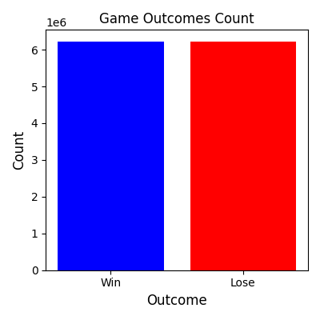

```python
label_counts = prep_df.groupBy("p1_win").count().collect()

labels = ['Win', 'Lose']
counts = [row["count"] for row in label_counts]

plt.figure(figsize=(4, 4))
plt.bar(labels, counts, color=['blue', 'red'])
plt.xlabel('Outcome', fontsize=12)
plt.ylabel('Count', fontsize=12)
plt.title('Game Outcomes Count', fontsize=12)
plt.tight_layout()
%matplot plt
```

Listed below are SparkML Models used with columns from the feature selection section. In the Machine Learning pipeline, the feature vectors undergo scaling with `StandardScaler` before being fed to the machine learning model

- `RandomForestClassifier`
- `GBTClassifier`
- `LogisticRegression`
- `LinearSVC`

```python
def run_models(ml_model, prep_df, return_results=False, show_importance=False):
    print(f"Running {ml_model.__class__.__name__}")
    feature_list = [i for i in prep_df.columns if all(substring not in i for substring in ["p1_win", "datetime"])]

    assembler = VectorAssembler(
        inputCols=feature_list,
        outputCol="features"
    )

    df_va = assembler.transform(prep_df)

    win_indexer = StringIndexer(inputCol="p1_win", outputCol="label")

    win_indexer_model = win_indexer.fit(df_va)
    df_va = win_indexer_model.transform(df_va)

    df_training = df_va.filter(F.col('datetime') <= '2023-07-31')
    df_test = df_va.filter(F.col('datetime') > '2023-07-31')

    scaler = StandardScaler(inputCol="features", outputCol="scaledFeatures")

    labelConverter = IndexToString(
        inputCol="prediction",
        outputCol="predictedLabel",
        labels=win_indexer_model.labels
    )

    pipeline = Pipeline(
        stages=[
            scaler,
            ml_model,
            labelConverter
        ]
    )

    model = pipeline.fit(df_training)
    train_predictions = model.transform(df_training)
    train_predictions = train_predictions.withColumn(
        "predictedLabel",
        train_predictions["predictedLabel"].cast(IntegerType())
    )

    test_predictions = model.transform(df_test)
    test_predictions = test_predictions.withColumn(
        "predictedLabel",
        test_predictions["predictedLabel"].cast(IntegerType())
    )

    ml_model = model.stages[1]
    if ml_model.__class__.__name__ in ["LinearSVCModel", "LogisticRegressionModel"]:
        importances = ml_model.coefficients.toArray()
    else:
        importances = ml_model.featureImportances.toArray()

    feature_names = feature_list
    importance_data = [(feature, float(importance)) for feature, importance in zip(feature_names, importances)]
    importance_df = spark.createDataFrame(importance_data, schema=["Feature", "Importance"])

    if show_importance:
        importance_df.orderBy(F.abs(F.col('Importance')).desc()).show(100, truncate=False)

    train_evaluator = MulticlassClassificationEvaluator(
        labelCol="label", predictionCol="prediction", metricName="accuracy")
    train_accuracy = train_evaluator.evaluate(train_predictions)
    print(f"Train acc: {train_accuracy}")

    test_evaluator = MulticlassClassificationEvaluator(
        labelCol="label", predictionCol="prediction", metricName="accuracy")
    test_accuracy = test_evaluator.evaluate(test_predictions)
    print(f"Test acc: {test_accuracy}")

    if not return_results:
        return None
    else:
        return ml_model, train_predictions, test_predictions, importance_df
```

```
VBox()
```

```
FloatProgress(value=0.0, bar_style='info', description='Progress:', layout=Layout(height='25px', width='50%'),…
```

```python
rf = RandomForestClassifier(
    labelCol="label",
    featuresCol="scaledFeatures",
    seed=2020, maxBins=1000
)
svc = LinearSVC(labelCol="label", featuresCol="scaledFeatures", maxIter=20)
gbt = GBTClassifier(labelCol="label", featuresCol="scaledFeatures", maxIter=20)
lr = LogisticRegression(
    maxIter=10, regParam=0.3, elasticNetParam=0.8,
    labelCol="label", featuresCol="scaledFeatures"
)
```

```
VBox()
```

```
FloatProgress(value=0.0, bar_style='info', description='Progress:', layout=Layout(height='25px', width='50%'),…
```

## Results and Discussion

### With trophies feature

`LinearSVC` seem to be the best model with a test accuracy score of 99.7%.

```python
run_models(rf, prep_df, return_results=False, show_importance=False)
run_models(gbt, prep_df, return_results=False, show_importance=False)
run_models(lr, prep_df, return_results=False, show_importance=False)
run_models(svc, prep_df, return_results=False, show_importance=False)
```

```
VBox()
```

```
FloatProgress(value=0.0, bar_style='info', description='Progress:', layout=Layout(height='25px', width='50%'),…
```

```
Running RandomForestClassifier
Train acc: 0.8654072513471296
Test acc: 0.8557170959024455
Running GBTClassifier
Train acc: 0.9248861517944598
Test acc: 0.9240305191890834
Running LogisticRegression
Train acc: 0.5003408454929403
Test acc: 0.5001353596699802
Running LinearSVC
Train acc: 0.9905794446016212
Test acc: 0.9970660135025449
```

Let's display the feature importances:

```python
svc_model, svc_train_predictions, svc_test_predictions, svc_importance_df = \
    run_models(svc, prep_df, return_results=True, show_importance=True)
```

```
VBox()
```

```
FloatProgress(value=0.0, bar_style='info', description='Progress:', layout=Layout(height='25px', width='50%'),…
```

```
Running LinearSVC
+-----------------------+----------------------+
|Feature                |Importance            |
+-----------------------+----------------------+
|p1_trophies            |-22.806540709791452   |
|p2_trophies            |22.760747227596543    |
|p2_elixir_total        |0.07479796360652341   |
|p1_rarity_rare_cnt     |0.06287011068850294   |
|p2_rarity_common_cnt   |-0.030829607746481292 |
|p1_type_spell_cnt      |0.029102162317612403  |
|p1_rarity_common_cnt   |0.02888257475877359   |
|p2_rarity_legendary_cnt|0.02735697700487782   |
|p2_rarity_rare_cnt     |-0.024698381022189526 |
|p1_score_7             |-0.023470636060177092 |
|p1_rarity_champion_cnt |-0.023328445066155758 |
|p2_rarity_epic_cnt     |-0.021663893361536145 |
|p1_type_troop_cnt      |-0.021454060229230767 |
|p1_rarity_epic_cnt     |0.015090249918683933  |
|p1_elixir_total        |-0.014042262984878115 |
|p2_score_5             |0.013081820962900642  |
|p2_rarity_champion_cnt |0.01298724690164731   |
|p1_score_3             |-0.01238466754244836  |
|p1_score_2             |-0.00972658238947054  |
|p1_total_score         |-0.008806835955398329 |
|p1_score_1             |-0.008232590474288544 |
|p1_score_4             |-0.007876438138993193 |
|p2_type_spell_cnt      |-0.007600613505269464 |
|p2_score_7             |0.007502389748442487  |
|p2_score_3             |0.007034666181438991  |
|p2_type_building_cnt   |0.0066060265343091925 |
|p1_score_6             |-0.005780376099864807 |
|p1_score_5             |-0.005062380979204724 |
|p2_total_score         |0.005018888774309766  |
|p2_score_1             |0.004748500180086208  |
|p2_score_2             |0.004731519506571234  |
|p1_rarity_legendary_cnt|0.004329341410636161  |
|p1_type_building_cnt   |-0.0039218798940825784|
|p2_score_6             |0.003911243624535796  |
|abs_diff_trophies      |0.0032934990792542196 |
|p2_score_4             |0.0015674957811862406 |
|p2_score_8             |-0.0014892835753709593|
|p2_type_troop_cnt      |9.123703934130265E-4  |
|p1_score_8             |-6.956451212099391E-4 |
|loser_trophies         |-1.49178529812622E-4  |
|winner_trophies        |-1.49178529812622E-4  |
|loser_card_contrib     |-1.9723169328573712E-5|
|percent_diff_trophies  |0.0                   |
|p2_is_evolved_false_cnt|0.0                   |
|p2_is_evolved_true_cnt |0.0                   |
|winner_card_contrib    |-0.0                  |
|p1_is_evolved_false_cnt|0.0                   |
|p1_is_evolved_true_cnt |0.0                   |
+-----------------------+----------------------+

Train acc: 0.9905794446016212
Test acc: 0.9970660135025449
```

Visualizing decision boundary of the `LinearSVC` model

```
VBox()
```

```
FloatProgress(value=0.0, bar_style='info', description='Progress:', layout=Layout(height='25px', width='50%'),…
```

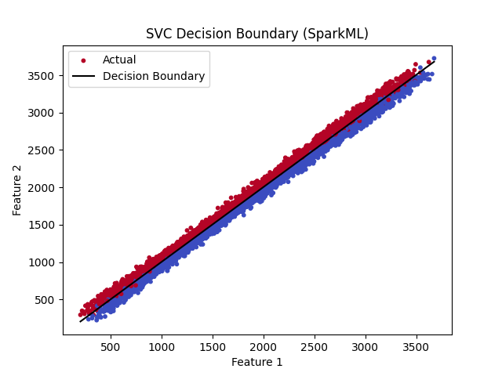

```python
results = svc_test_predictions.select("features", "label", "prediction").limit(100_000).collect()
plt.close('all')
features = [row["features"] for row in results]
labels = [row["label"] for row in results]
predictions = [row["prediction"] for row in results]

X = np.array([list(vec) for vec in features])  # Convert DenseVector to numpy array
y = np.array(labels)
y_pred = np.array(predictions)

plt.scatter(X[:, 0], X[:, 1], c=y, cmap="coolwarm", s=10, label="Actual")

coef = svc_model.coefficients
intercept = svc_model.intercept
x_vals = np.linspace(X[:, 0].min(), X[:, 0].max(), 100)
y_vals = -(coef[0] * x_vals + intercept) / coef[1]
plt.plot(x_vals, y_vals, "k-", label="Decision Boundary")

plt.xlabel("Feature 1")
plt.ylabel("Feature 2")
plt.title("SVC Decision Boundary (SparkML)")
plt.legend()
%matplot plt
```

```
VBox()
```

```
FloatProgress(value=0.0, bar_style='info', description='Progress:', layout=Layout(height='25px', width='50%'),…
```

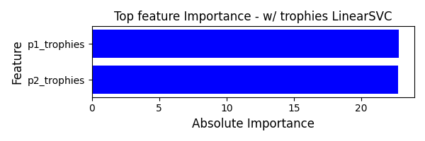

```python
df_abs = svc_importance_df.withColumn("Absolute Importance", F.abs(F.col("Importance")))
df_top_10 = df_abs.orderBy(F.desc("Absolute Importance")).limit(2)
top_10_data = df_top_10.select("Feature", "Absolute Importance").toPandas()

plt.figure(figsize=(6, 2))
plt.barh(top_10_data["Feature"], top_10_data["Absolute Importance"], color='blue')
plt.xlabel("Absolute Importance", fontsize=12)
plt.ylabel("Feature", fontsize=12)
plt.title("Top feature Importance - w/ trophies LinearSVC", fontsize=12)
plt.gca().invert_yaxis()
plt.tight_layout()
%matplot plt
```

The decision boundary observed in the plot effectively delineates the two classes, suggesting a clear relationship between the features `p1_trophies` and `p2_trophies` in predicting match outcomes. This finding underscores the importance of these features in the model's decision-making process.

The strong performance of the `LinearSVC` model aligns with this observation, as linear classifiers tend to perform well when features are linearly separable or exhibit a straightforward relationship. The model's relatively high accuracy indicates that `p1_trophies` and `p2_trophies` likely contribute significantly to the prediction of match outcomes.

Interestingly, the feature importance reveals an intriguing insight: a lower-rated player often prevails over a higher-rated opponent. This pattern might suggest the presence of a "challenger advantage." Lower-rated players may be underestimated by their higher-rated counterparts, leading to under-preparation or overconfidence in matches. Alternatively, the data could reflect strategic matchups or hidden factors such as differing levels of motivation, risk-taking, or psychological pressure.

To bring out other factors that may affect match outcome we may opt to drop this feature and look at the next top predictors.

### Without trophies as feature

Attempting to run without strongest predictors `p1_trohpies` and `p2_trophies`. `GBTClassifier` seem to be the best model with a test accuracy score of 94.2%.

```
Note: ignore the key error exception, spark widget in aws seem to have lost track on what stage we are in but still runs the output.
See: https://stackoverflow.com/questions/58910023/keyerror-when-training-a-model-with-pyspark-ml-on-aws-emr-with-data-from-s3-buck
```

```python
run_models(rf, prep_df_no_trop, return_results=False, show_importance=False)
run_models(gbt, prep_df_no_trop, return_results=False, show_importance=False)
run_models(lr, prep_df_no_trop, return_results=False, show_importance=False)
run_models(svc, prep_df_no_trop, return_results=False, show_importance=False)
```

```
VBox()
```

```
FloatProgress(value=0.0, bar_style='info', description='Progress:', layout=Layout(height='25px', width='50%'),…
```

[output not shown]

```
Running RandomForestClassifier
Train acc: 0.8238213168197294
Test acc: 0.8118935075104324
Running GBTClassifier
Train acc: 0.9460099770699539
Test acc: 0.9427356977110608
Running LogisticRegression
Train acc: 0.5003408454929403
Test acc: 0.5001353596699802
Running LinearSVC
Train acc: 0.5145785143736802
Test acc: 0.5110823044088578
```

```python
gbt_model, gbt_train_predictions, gbt_test_predictions, gbt_importance_df = \
    run_models(gbt, prep_df_no_trop, return_results=True, show_importance=True)
```

```
VBox()
```

```
FloatProgress(value=0.0, bar_style='info', description='Progress:', layout=Layout(height='25px', width='50%'),…
```

[output not shown]

```
Running GBTClassifier
+-----------------------+----------------------+
|Feature                |Importance            |
+-----------------------+----------------------+
|loser_card_contrib     |0.3330421474050917    |
|winner_card_contrib    |0.3054412288191111    |
|p1_total_score         |0.25404485705884905   |
|p2_total_score         |0.10046825733974983   |
|p2_score_6             |0.005289579649328246  |
|p2_score_8             |7.909567679504799E-4  |
|p2_score_2             |4.6339420926307025E-4 |
|p1_score_8             |1.686172161717989E-4  |
|p1_score_2             |1.0342193426199028E-4 |
|p1_score_4             |6.711737003262856E-5  |
|p1_score_6             |4.942091592921426E-5  |
|p1_type_building_cnt   |2.889810970064493E-5  |
|p1_type_troop_cnt      |2.3263395914186676E-5 |
|p2_score_4             |1.8839808645973418E-5 |
|p1_rarity_rare_cnt     |7.00592010065468E-17  |
|p1_rarity_epic_cnt     |4.2723963619599335E-17|
|p1_rarity_champion_cnt |7.390638256470977E-18 |
|percent_diff_trophies  |5.770772337244461E-18 |
|winner_trophies        |5.315185047462005E-18 |
|p2_rarity_legendary_cnt|3.0878694085255424E-18|
|p2_type_spell_cnt      |8.151668250978188E-19 |
|p2_rarity_rare_cnt     |2.08860275535035E-19  |
|p1_rarity_legendary_cnt|0.0                   |
|p1_elixir_total        |0.0                   |
|p2_type_building_cnt   |0.0                   |
|p1_rarity_common_cnt   |0.0                   |
|p2_is_evolved_true_cnt |0.0                   |
|p2_rarity_epic_cnt     |0.0                   |
|p1_is_evolved_true_cnt |0.0                   |
|p1_score_5             |0.0                   |
|p2_is_evolved_false_cnt|0.0                   |
|p2_type_troop_cnt      |0.0                   |
|p2_score_1             |0.0                   |
|p1_score_1             |0.0                   |
|p1_score_3             |0.0                   |
|p2_score_7             |0.0                   |
|p1_type_spell_cnt      |0.0                   |
|p1_score_7             |0.0                   |
|p2_rarity_champion_cnt |0.0                   |
|abs_diff_trophies      |0.0                   |
|p2_score_5             |0.0                   |
|p2_elixir_total        |0.0                   |
|p2_rarity_common_cnt   |0.0                   |
|p2_score_3             |0.0                   |
|p1_is_evolved_false_cnt|0.0                   |
|loser_trophies         |0.0                   |
+-----------------------+----------------------+

Train acc: 0.9460114297944843
Test acc: 0.9427359364406375
```

```
VBox()
```

```
FloatProgress(value=0.0, bar_style='info', description='Progress:', layout=Layout(height='25px', width='50%'),…
```

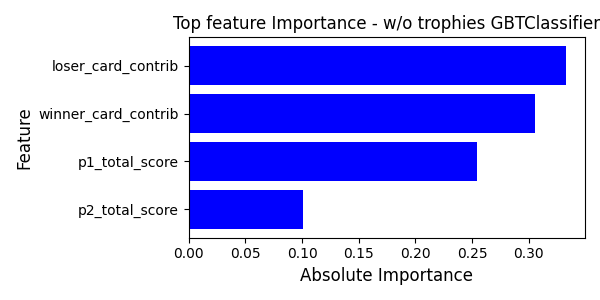

```python
df_abs = gbt_importance_df.withColumn("Absolute Importance", F.abs(F.col("Importance")))
df_top_10 = df_abs.orderBy(F.desc("Absolute Importance")).limit(4)
top_10_data = df_top_10.select("Feature", "Absolute Importance").toPandas()

plt.figure(figsize=(6, 3))
plt.barh(top_10_data["Feature"], top_10_data["Absolute Importance"], color='blue')
plt.xlabel("Absolute Importance", fontsize=12)
plt.ylabel("Feature", fontsize=12)
plt.title("Top feature Importance - w/o trophies GBTClassifier", fontsize=12)
plt.gca().invert_yaxis()
plt.tight_layout()
%matplot plt
```

After observing the significant influence of trophies (`p1_trophies` and `p2_trophies`) as predictors of match outcomes, we explored the model's behavior without these features. Interestingly, the sum of the netscore emerged as the dominant factor in determining game outcomes.

This highlights synergy of their card decks. The finding suggests that certain deck combinations are inherently more effective, winning more often regardless of the players' individual ratings. This insight highlights the importance of strategic deck-building in achieving consistent success.

## Conclusion

To conclude, our analysis reveals that player ratings, as reflected by trophies, play a significant role in predicting match outcomes, but when removed, the sum of the netscore emerged as the next best predictor. These insights emphasize the need to consider both individual player performance and strategic deck-building when evaluating and predicting competitive match results.